# Question 1

# Question 3

```python
root_path = 'C:/Users/Ogulcan/Desktop/CS 545/Homeworks/HW_4/UCI HAR Dataset/test/Inertial Signals' # Change current path to the desired one
subject_name = 'vl1'
full_path = '%s' % (root_path)
os.chdir(root_path)

labels=np.zeros([2947,1])


with open('y_test.txt','r') as file:
    i=0
    # reading each line
    for line in file:
        j=0
        labels[i,0]=int(line)
        i=i+1
```

```python
acceleration_data=np.zeros([1878,128,3])
labels_final=np.zeros([1878,1])

with open('total_acc_x_test.txt','r') as file:
    i=0
    k=0
    # reading each line
    for line in file:
        j=0
        if labels[i,0]==[1] or labels[i,0]==[2] or labels[i,0]==[3] or labels[i,0]==[4]:
            for word in line.split():
                acceleration_data[k,j,0]=float(word)
                j=j+1
            labels_final[k,0]=labels[i,0]
            i=i+1
            k=k+1
        else:
            i=i+1




with open('total_acc_y_test.txt','r') as file:
    i=0
    k=0
    # reading each line
    for line in file:
        j=0
        if labels[i,0]==[1] or labels[i,0]==[2] or labels[i,0]==[3] or labels[i,0]==[4]:
            for word in line.split():
                acceleration_data[k,j,1]=float(word)
                j=j+1
            i=i+1
            k=k+1
        else:
            i=i+1

with open('total_acc_z_test.txt','r') as file:
    i=0
    k=0
    # reading each line
    for line in file:
        j=0
        if labels[i,0]==[1] or labels[i,0]==[2] or labels[i,0]==[3] or labels[i,0]==[4]:
            for word in line.split():
                acceleration_data[k,j,2]=float(word)
                j=j+1
            i=i+1
            k=k+1
        else:
            i=i+1


acceleration_data_train, acceleration_data_test, labels_train, labels_test = train_test_split(acceleration_data, labels_final, test_size=0.5)
```

```python
label_data_1=acceleration_data_train[(labels_train==1)[:,0],:,:]
label_data_2=acceleration_data_train[(labels_train==2)[:,0],:,:]
label_data_3=acceleration_data_train[(labels_train==3)[:,0],:,:]
label_data_4=acceleration_data_train[(labels_train==4)[:,0],:,:]

VAR_1=np.reshape(label_data_1,[np.shape(label_data_1)[1]*np.shape(label_data_1)[0],3])
VAR_2=np.reshape(label_data_2,[np.shape(label_data_2)[1]*np.shape(label_data_2)[0],3])
VAR_3=np.reshape(label_data_3,[np.shape(label_data_3)[1]*np.shape(label_data_3)[0],3])
VAR_4=np.reshape(label_data_4,[np.shape(label_data_4)[1]*np.shape(label_data_4)[0],3])

N=10

model_1 = VAR(VAR_1)
results_1 = model_1.fit(maxlags=N, ic='aic')

model_2 = VAR(VAR_2)
results_2 = model_2.fit(maxlags=N, ic='aic')

model_3 = VAR(VAR_3)
results_3 = model_3.fit(maxlags=N, ic='aic')

model_4 = VAR(VAR_4)
results_4 = model_4.fit(maxlags=N, ic='aic')
```

```python
def predictor (data,N,results):
    predictions = np.zeros([len(data),3])
    for i in range(len(data)-N):
        predictions[N+i,:]=results.forecast(data[i:(N+i),:],1)
    return predictions
```

```python
def classifier(data,N,results_1 ,results_2 ,results_3 ,results_4 ):

    label_1_pr=predictor(data,N,results_1)
    label_2_pr=predictor(data,N,results_2)
    label_3_pr=predictor(data,N,results_3)
    label_4_pr=predictor(data,N,results_4)

    err_1=np.sum(abs(label_1_pr[N:,:]-data[N:,:]))
    err_2=np.sum(abs(label_2_pr[N:,:]-data[N:,:]))
    err_3=np.sum(abs(label_3_pr[N:,:]-data[N:,:]))
    err_4=np.sum(abs(label_4_pr[N:,:]-data[N:,:]))

    min_value=min([err_1,err_2,err_3,err_4])
    label=[err_1,err_2,err_3,err_4].index(min_value)+1

    return label
```

```python
label_predict=np.zeros([len(acceleration_data_test),1])
for i in range(len(acceleration_data_test)):

    label_predict[i]=classifier(acceleration_data_test[i,:,:],N,results_1 ,results_2 ,results_3 ,results_4)
```

```python
label_predict_train=np.zeros([len(acceleration_data_train),1])
for i in range(len(acceleration_data_train)):

    label_predict_train[i]=classifier(acceleration_data_train[i,:,:],N,results_1 ,results_2 ,results_3 ,results_4)
```

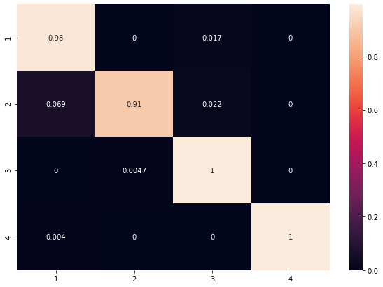

```python
cm_test=metrics.confusion_matrix(labels_test,label_predict)
df_cm_test = pd.DataFrame(cm_test, index = [i for i in "1234"],
                  columns = [i for i in "1234"])

df_cm_test_norm = df_cm_test.div(cm_test.sum(axis=1), axis=0)

plt.figure(figsize = (10,7))
sn.heatmap(df_cm_test_norm, annot=True)
```

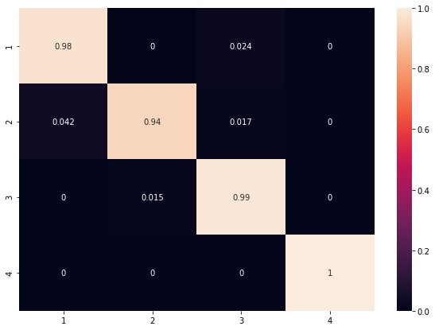

```python
cm_train=metrics.confusion_matrix(labels_train,label_predict_train)
df_cm_train = pd.DataFrame(cm_train, index = [i for i in "1234"],
                  columns = [i for i in "1234"])

df_cm_train_norm = df_cm_train.div(cm_train.sum(axis=1), axis=0)

plt.figure(figsize = (10,7))
sn.heatmap(df_cm_train_norm, annot=True)
```

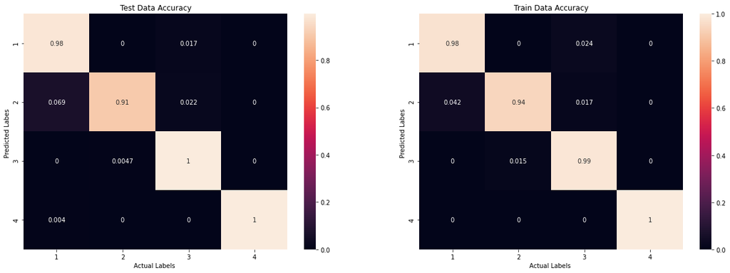

```python
plt.figure(figsize=(21,7))

plt.subplot(1, 2, 1) # row 1, col 2 index 1
sn.heatmap(df_cm_test_norm, annot=True)
plt.title("Test Data Accuracy")
plt.xlabel('Actual Labels ')
plt.ylabel('Predicted Labes ')

plt.subplot(1, 2, 2) # index 2
sn.heatmap(df_cm_train_norm, annot=True)
plt.title("Train Data Accuracy")
plt.xlabel('Actual Labels ')
plt.ylabel('Predicted Labes ')


plt.show()
```

I played with number of samples (N) to maximize our prediction, and we can see that our classifier performs really well for the training data. For the test data we see that performance does not degrage as much and we get almost all predictions over 0.9. For VAR implementation, I used 'stats' library and I am implemented my own predition function to predict every data in the training set. So, I created some auxilary functions to make use of the already available library. I believe the accuracy can be improved by using bigger data set or preconditioning (processing) the acceleration data. We also see that model 3 and 4 produces least errors and highest error occurs for model 2. I think that is also related the the data quality and distingusibility of the data.